# Cyclistic Bike-Share Usage Analysis: Members vs. Casual Riders

2025-11-12

# Purpose Statement

The business objective is to identify how casual and annual riders use Cyclistic bikes differently in order to identify opportunities to convert casual riders to annual members. Understanding any behavioral differences will guide the Cyclistic marketing team in designing targeted strategies to increase membership rates.

# Executive Summary

Analysis of Cyclistic bike-share data reveals key behavioral differences: casual riders take dramatically longer rides than members (~90 minutes vs. ~13 minutes for members) but ride much less frequently. Members prefer weekday usage (likely commuting) while casual riders prefer weekends. Casual riders tend to ride for a longer duration on Thursday and Friday.

Recommendation: Cyclistic should target casual riders, especially weekend and long-distance riders, with incentives to become annual members. The messaging should highlight the cost savings of membership for long rides, the value of unlimited weekend trips, and the overall convenience of being a member. Converting even a small percentage of casual riders to members would significantly increase recurring revenue, since annual members generate predictable income.

## Data Sources

The analysis uses historical data of Cyclistic bike-share trips from Q1 of 2019 and Q1 of 2020. The data is publicly available by Motivate International Inc. under the [license](https://divvybikes.com/data-license-agreement). Cyclistic is a fictional company, but it uses real public bike-share data from Chicago’s Divvy system.

The data is in CSV format and has trip information, including trip duration, station ID, bike ID, start and end stations, and timestamps. In addition, these datasets include rider information such as subscriber (Casual vs. Member), gender, and age.

No personally identifiable information, like address, phone number, or name, is included in the datasets.

## Data Processing and Cleaning

```r
library(tidyverse)
library(dplyr)
library(readr)
library(scales)
```

The 2019 and 2020 datasets were imported and validated to ensure correct structure.

```r
q1_2019 <- read.csv("data/Divvy_2019.csv")

q1_2020 <- read.csv("data/Divvy_2020.csv")

str(q1_2019)
```

```
## 'data.frame':    365069 obs. of  14 variables:
##  $ trip_id          : int  21742443 21742444 21742445 21742446 21742447 21742448 21742449 21742450 21742451 21742452 ...
##  $ start_time       : chr  "1/1/2019 0:04" "1/1/2019 0:08" "1/1/2019 0:13" "1/1/2019 0:13" ...
##  $ end_time         : chr  "1/1/2019 0:11" "1/1/2019 0:15" "1/1/2019 0:27" "1/1/2019 0:43" ...
##  $ ride_length      : chr  "0:06:30" "0:07:21" "0:13:49" "0:29:43" ...
##  $ day_of_week      : int  3 3 3 3 3 3 3 3 3 3 ...
##  $ bikeid           : int  2167 4386 1524 252 1170 2437 2708 2796 6205 3939 ...
##  $ tripduration     : chr  "390" "441" "829" "1,783.00" ...
##  $ from_station_id  : int  199 44 15 123 173 98 98 211 150 268 ...
##  $ from_station_name: chr  "Wabash Ave & Grand Ave" "State St & Randolph St" "Racine Ave & 18th St" "California Ave & Milwaukee Ave" ...
##  $ to_station_id    : int  84 624 644 176 35 49 49 142 148 141 ...
##  $ to_station_name  : chr  "Milwaukee Ave & Grand Ave" "Dearborn St & Van Buren St (*)" "Western Ave & Fillmore St (*)" "Clark St & Elm St" ...
##  $ usertype         : chr  "Subscriber" "Subscriber" "Subscriber" "Subscriber" ...
##  $ gender           : chr  "Male" "Female" "Female" "Male" ...
##  $ birthyear        : int  1989 1990 1994 1993 1994 1983 1984 1990 1995 1996 ...
```

```r
str(q1_2020)
```

```
## 'data.frame':    426887 obs. of  15 variables:
##  $ ride_id           : chr  "EACB19130B0CDA4A" "8FED874C809DC021" "789F3C21E472CA96" "C9A388DAC6ABF313" ...
##  $ rideable_type     : chr  "docked_bike" "docked_bike" "docked_bike" "docked_bike" ...
##  $ started_at        : chr  "1/21/2020 20:06" "1/30/2020 14:22" "1/9/2020 19:29" "1/6/2020 16:17" ...
##  $ ended_at          : chr  "1/21/2020 20:14" "1/30/2020 14:26" "1/9/2020 19:32" "1/6/2020 16:25" ...
##  $ ride_length       : chr  "0:07:31" "0:03:43" "0:02:51" "0:08:49" ...
##  $ day_of_week       : int  3 5 5 2 5 6 6 6 6 6 ...
##  $ start_station_name: chr  "Western Ave & Leland Ave" "Clark St & Montrose Ave" "Broadway & Belmont Ave" "Clark St & Randolph St" ...
##  $ start_station_id  : int  239 234 296 51 66 212 96 96 212 38 ...
##  $ end_station_name  : chr  "Clark St & Leland Ave" "Southport Ave & Irving Park Rd" "Wilton Ave & Belmont Ave" "Fairbanks Ct & Grand Ave" ...
##  $ end_station_id    : int  326 318 117 24 212 96 212 212 96 100 ...
##  $ start_lat         : num  42 42 41.9 41.9 41.9 ...
##  $ start_lng         : num  -87.7 -87.7 -87.6 -87.6 -87.6 ...
##  $ end_lat           : num  42 42 41.9 41.9 41.9 ...
##  $ end_lng           : num  -87.7 -87.7 -87.7 -87.6 -87.6 ...
##  $ member_casual     : chr  "member" "member" "member" "member" ...
```

The 2019 and 2020 datasets use different column names, so the columns in the q1_2019 table were renamed to match the naming of the columns in q1_2020. This ensures the datasets are compatible with each other before merging.

```r
q1_2019 <- rename(q1_2019,
                   ride_id = trip_id,
                   started_at = start_time,
                   ended_at = end_time,
                   start_station_name = from_station_name,
                   start_station_id = from_station_id,
                   end_station_id = to_station_id,
                   end_station_name = to_station_name,
                   member_casual = usertype,
                   rideable_type = bikeid
                   )
```

The data types for bike_id and rideable_type were numeric, so they were converted to character types to match the q1_2020 table.

```r
q1_2019 <- mutate(q1_2019, ride_id = as.character(ride_id),
                  rideable_type = as.character(rideable_type))
```

The data tables were combined into one table *all_trips* for unified cleaning and analysis.

```r
all_trips <- bind_rows(q1_2019, q1_2020)
```

To maintain consistency across both years, columns not in both datasets were excluded.

```r
all_trips <- all_trips %>%
  select(-c(gender, birthyear,start_lat,start_lng,end_lat,end_lng, tripduration))
```

## Preparation for Analysis

In the member_casual column, there are two names for members (“member” and “Subscriber”) and two names for casual riders (“Customer” and “casual”).

```r
table(all_trips$member_casual)
```

```
##
##     casual   Customer     member Subscriber
##      48480      23163     378407     341906
```

These were consolidated to “member” and “casual”.

```r
all_trips <- all_trips %>%
  mutate(member_casual = recode(member_casual, "Subscriber" = "member", "Customer" = "casual"))

table(all_trips$member_casual)
```

```
##
## casual member
##  71643 720313
```

The date, month, day, year, and day_of_week columns were added to analyze rider trends across different periods of time.

```r
all_trips$date <- as.Date(all_trips$started_at, format = "%m/%d/%Y %H:%M")
all_trips$month <- format(as.Date(all_trips$date), "%m")
all_trips$day <- format(as.Date(all_trips$date), "%d")
all_trips$year <- format(as.Date(all_trips$date), "%Y")
all_trips$day_of_week <- format(as.Date(all_trips$date), "%A")
```

A new calculated column for ride_length was created by subtracting the started_at from the ended_at column. The types were converted from character to POSIXct to ensure compatibility with the difftime function.

```r
all_trips$started_at <- as.POSIXct(all_trips$started_at,
                                   format = "%m/%d/%Y %H:%M")
all_trips$ended_at <- as.POSIXct(all_trips$ended_at,
                                 format = "%m/%d/%Y %H:%M")

all_trips$ride_length <- difftime(all_trips$ended_at,all_trips$started_at)
```

Rides starting at the “HQ QR” station represent internal corporate tests, so they were excluded. Negative ride lengths were also excluded to prevent inaccuracies.

```r
all_trips_v2 <- all_trips[!(all_trips$start_station_name == "HQ QR" | all_trips$ride_length<0), ]
head(all_trips_v2)
```

```
##    ride_id          started_at            ended_at ride_length day_of_week
## 1 21742443 2019-01-01 00:04:00 2019-01-01 00:11:00    420 secs     Tuesday
## 2 21742444 2019-01-01 00:08:00 2019-01-01 00:15:00    420 secs     Tuesday
## 3 21742445 2019-01-01 00:13:00 2019-01-01 00:27:00    840 secs     Tuesday
## 4 21742446 2019-01-01 00:13:00 2019-01-01 00:43:00   1800 secs     Tuesday
## 5 21742447 2019-01-01 00:14:00 2019-01-01 00:20:00    360 secs     Tuesday
## 6 21742448 2019-01-01 00:15:00 2019-01-01 00:19:00    240 secs     Tuesday
##   rideable_type start_station_id                  start_station_name
## 1          2167              199              Wabash Ave & Grand Ave
## 2          4386               44              State St & Randolph St
## 3          1524               15                Racine Ave & 18th St
## 4           252              123      California Ave & Milwaukee Ave
## 5          1170              173 Mies van der Rohe Way & Chicago Ave
## 6          2437               98          LaSalle St & Washington St
##   end_station_id               end_station_name member_casual       date month
## 1             84      Milwaukee Ave & Grand Ave        member 2019-01-01    01
## 2            624 Dearborn St & Van Buren St (*)        member 2019-01-01    01
## 3            644  Western Ave & Fillmore St (*)        member 2019-01-01    01
## 4            176              Clark St & Elm St        member 2019-01-01    01
## 5             35        Streeter Dr & Grand Ave        member 2019-01-01    01
## 6             49        Dearborn St & Monroe St        member 2019-01-01    01
##   day year
## 1  01 2019
## 2  01 2019
## 3  01 2019
## 4  01 2019
## 5  01 2019
## 6  01 2019
```

## Descriptive Analysis

### Ride Counts: Members vs. Casual Riders

```r
table(all_trips_v2$member_casual)
```

```
##
## casual member
##  67877 720312
```

This graph illustrates the difference in ride count between casual and member riders. It also shows that members tend to ride much more during the week compared to on the weekend. The opposite is true with casual riders.

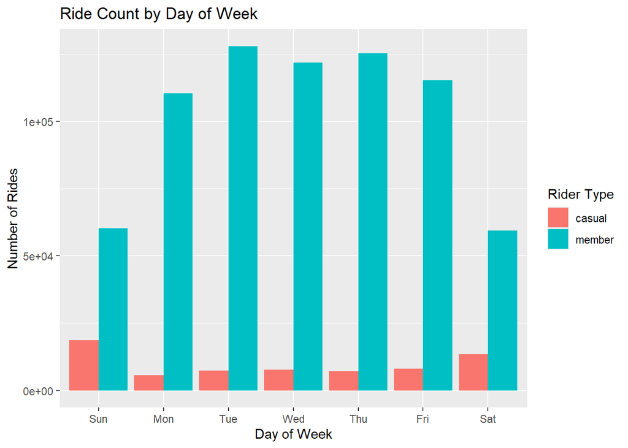

```r
all_trips_v2 %>%
  mutate(weekday = wday(started_at, label = TRUE)) %>%
  group_by(member_casual, weekday) %>%
  summarise(number_of_rides = n()
            ,average_duration = mean(ride_length)) %>%
  arrange(member_casual, weekday)  %>%
  ggplot(aes(x = weekday, y = number_of_rides, fill=member_casual)) + geom_col(position="dodge") + labs(title = "Ride Count by Day of Week", x = "Day of Week", y = "Number of Rides", fill = "Rider Type")
```

### Ride Length: Members vs. Casual Riders

This section examines the average ride length taken by members and casual riders to understand how long they ride for. The table shows that casual riders ride for significantly more time than member riders.

The low p-value indicates overwhelming statistical significance of this difference.

```r
ride_length <- aggregate(all_trips_v2$ride_length ~ all_trips_v2$member_casual, FUN = mean)

ride_length$ride_length_min = as.numeric(ride_length$`all_trips_v2$ride_length`/ 60)

ride_length
```

```
##   all_trips_v2$member_casual all_trips_v2$ride_length ride_length_min
## 1                     casual           5370.7474 secs        89.51246
## 2                     member            795.1109 secs        13.25185
```

```r
t.test(ride_length ~ member_casual, data = all_trips_v2)
```

```
##
##  Welch Two Sample t-test
##
## data:  ride_length by member_casual
## t = 11.912 secs, df = 68220, p-value < 2.2e-16
## alternative hypothesis: true difference in means between group casual and group member is not equal to 0
## 95 percent confidence interval:
##  3822.748 secs 5328.525 secs
## sample estimates:
## Time differences in secs
## mean in group casual mean in group member
##            5370.7474             795.1109
```

This section examines the average ride length grouped by weekday. The graph shows the days of the week and the average ride_length for each day. The graph shows that casual riders ride longer on Thursday and Friday compared to the rest of the week.

```
## Defaulting to continuous.
```

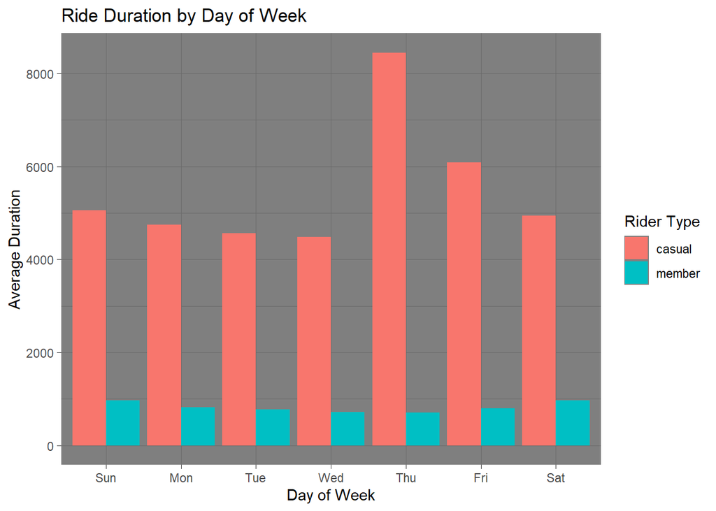

```r
all_trips_v2 %>%
  mutate(weekday = wday(started_at, label = TRUE)) %>%
  group_by(member_casual, weekday) %>%
  summarise(number_of_rides = n()
            ,average_duration = mean(ride_length)) %>%
  arrange(member_casual, weekday)  %>%
  ggplot(aes(x = weekday, y = average_duration, fill = member_casual)) +
  geom_col(position = "dodge") + labs(title = "Ride Duration by Day of Week", x = "Day of Week", y = "Average Duration", fill = "Rider Type") + theme_dark()
```

From this analysis, we can confirm the following about rider behavior.

- Casual riders take less rides on average compared to members, but they ride for much longer.
- Casual riders take the most rides on the weekends, while members take the most rides during the week.
- Casual riders ride for longer on Thursdays and Fridays compared to the rest of the week.